# 3FGL Source Classification vs. 4FGL Discovery

### Data Source

“FGL4.rData” are downloaded from Fermi LAT data products. “FGL4_tidy_for_FGL3.rData” are processed 4FGL data catalog. (https://fermi.gsfc.nasa.gov/ssc/data/access/ ). See the processing steps [here](https://sherr3h.github.io/2020-03-29-Processing-Fermi-LAT-4FGL-Data-Catalog/).

“FGL3_results.rData” and related scripts are associated with the following publication:

“Classification and Ranking of Fermi LAT Gamma-ray Sources from the 3FGL Catalog Using Machine Learning Techniques”,

Saz Parkinson, P. M. (HKU/LSR, SCIPP), Xu, H. (HKU), Yu, P. L. H. (HKU), Salvetti, D. (INAF-Milan), Marelli, M. (INAF-Milan), and Falcone, A. D. (Penn State), The Astrophysical Journal, 2016, in press (http://arxiv.org/abs/1602.00385)

```r
library(dplyr)
library(devtools)
library(ggplot2)

load("fermicatsR/data/FGL4.rData")
load("fermicatsR/FGL3_results.rdata")
load("fermicatsR/FGL4_tidy_for_FGL3.rData")
```

### Check 3FGL classification results based on 4FGL new discovery

Out of 3033 3FGL sources, 469 are missing in 4FGL for various reasons.

Important variables:

- Variability Index
- Curvature
- Hardneww Ratio [Ackerman et al. 2012]:

$hr_{ij} = \frac{EnergyFlux_j - EnergyFlux_i} {EnergyFlux_j + EnergyFlux_i}$, where

$EnergyFlux_{i}$ is log photon flux in energy bands. hr = -1 for very soft source (high $EnergyFlux_j = 0$), +1 for very hard source (low $EnergyFlux_i = 0$)

#### 1. 3FGL Unassociated sources with significance > 10

```r
FGL3_unassoc_signif_res <- FGL3_results %>%
        filter(CLASS1 == "") %>%
        filter(Signif > 10) %>%       #>10: 149 obs
        filter(LR_Pred==RF_Pred) %>%
        # filter(LR_Pred=="PSR") %>%
        arrange(desc(Signif))

FGL3_unassoc_res_FGL4 <- inner_join(FGL3_unassoc_signif_res, FGL4_tidy_for_FGL3,
                                    by = c("Source_Name" = "FGL3_Source_name")) %>% #>10: 108
                        filter (CLASS1.y != "")  #>10: 47

FGL3_accuracy_pred <- mutate(FGL3_unassoc_res_FGL4,
       accurate=(FGL3_unassoc_res_FGL4$LR_Pred==FGL3_unassoc_res_FGL4$class))

table(FGL3_accuracy_pred$class,FGL3_accuracy_pred$accurate)
```

```
##
##         FALSE TRUE
##   AGN       5   17
##   PSR       0    0
##   Other     5    0
```

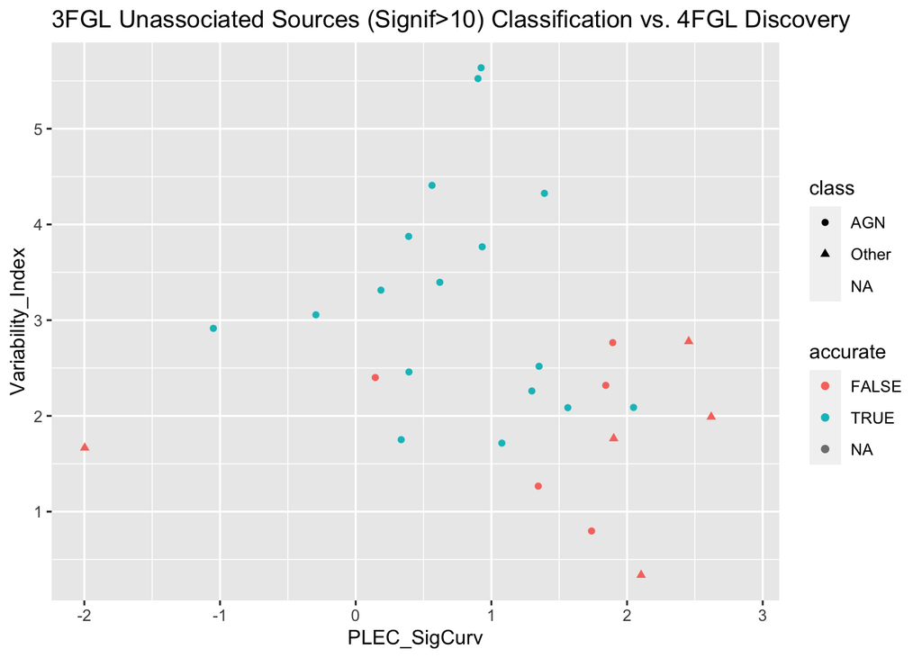

```r
ggplot(FGL3_accuracy_pred, aes(x=PLEC_SigCurv, y=Variability_Index, shape=class, color= accurate)) +
        geom_point() +
        labs(title="3FGL Unassociated Sources (Signif>10) Classification vs. 4FGL Discovery",
             x="PLEC_SigCurv", y = "Variability_Index")
```

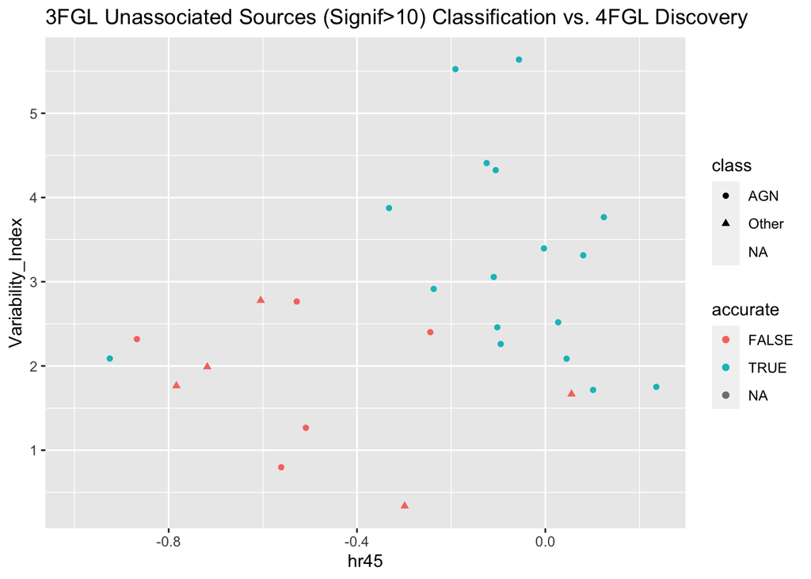

```r
ggplot(FGL3_accuracy_pred, aes(x=hr45, y=Variability_Index, shape=class, color= accurate)) +
        geom_point() +
        labs(title="3FGL Unassociated Sources (Signif>10) Classification vs. 4FGL Discovery",
             x="hr45", y = "Variability_Index")
```

#### 2. 3FGL Unassociated sources with significance > 4 (Whole Catalog)

```r
FGL3_unassoc_results <- FGL3_results %>%
        filter(CLASS1 == "") %>%
        filter(Signif > 4) %>%      #4: 921 obs
        filter(LR_Pred==RF_Pred) %>%
        # filter(LR_Pred=="PSR") %>%
        arrange(desc(Signif))

FGL3_unassoc_res_FGL4_all <- inner_join(FGL3_unassoc_results, FGL4_tidy_for_FGL3,
                                    by = c("Source_Name" = "FGL3_Source_name")) %>% #>4: 566
                             filter (CLASS1.y != "" | CLASS2 != "") #315

FGL3_accuracy_pred_all <- mutate(FGL3_unassoc_res_FGL4_all,
                             accurate=(FGL3_unassoc_res_FGL4_all$LR_Pred==FGL3_unassoc_res_FGL4_all$class))

table(FGL3_accuracy_pred_all$class,FGL3_accuracy_pred_all$accurate)
```

```
##
##         FALSE TRUE
##   AGN      12  233
##   PSR       0    0
##   Other    37    0
```

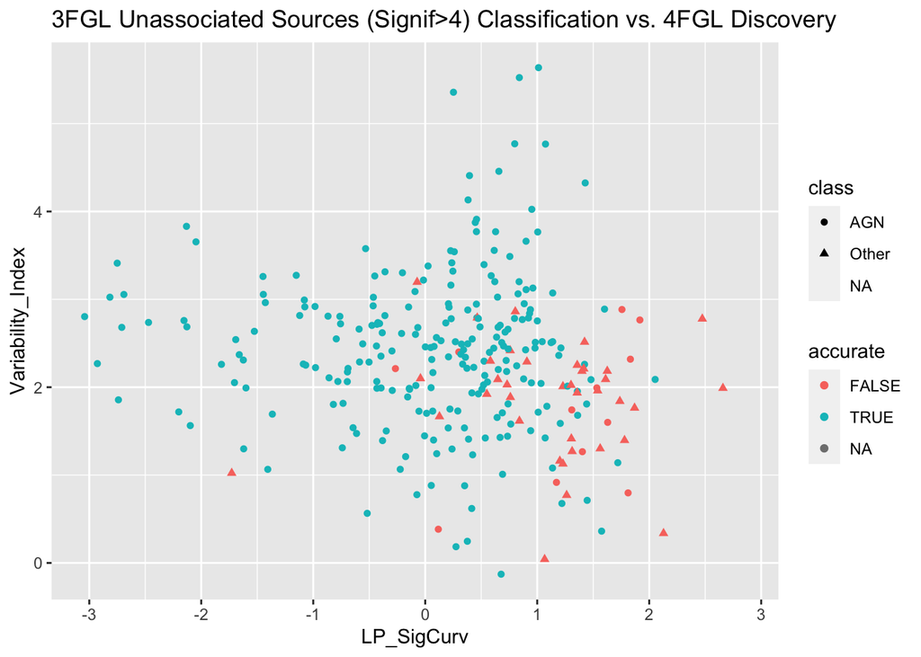

```r
ggplot(FGL3_accuracy_pred_all, aes(x=LP_SigCurv, y=Variability_Index, shape=class, color= accurate)) +
        geom_point() +
        labs(title="3FGL Unassociated Sources (Signif>4) Classification vs. 4FGL Discovery",
             x="LP_SigCurv", y = "Variability_Index")
```

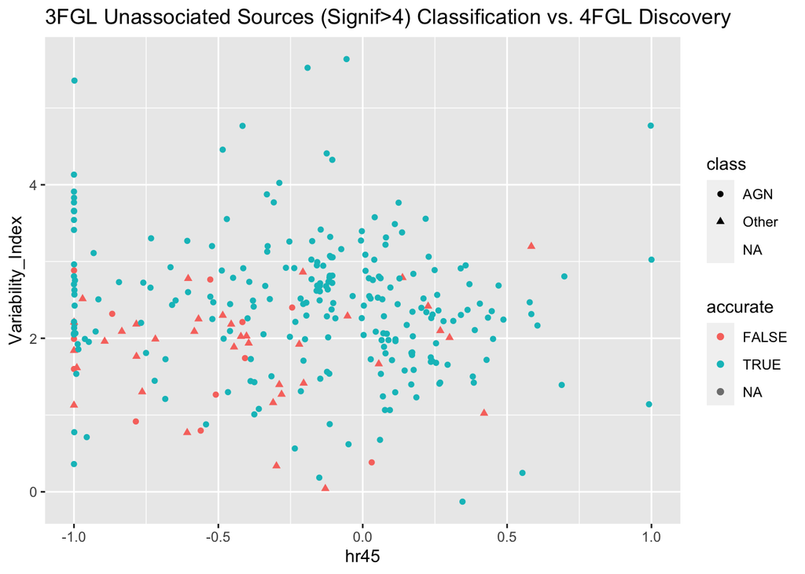

```r
ggplot(FGL3_accuracy_pred_all, aes(x=hr45, y=Variability_Index, shape=class, color= accurate)) +
        geom_point() +
        labs(title="3FGL Unassociated Sources (Signif>4) Classification vs. 4FGL Discovery",
             x="hr45", y = "Variability_Index")
```